# Ch02 Applied Exercise 08 Notebook

Bruce Hartman

University of St. Francis

2026-08-31 Revised 2026-10-15T08:43:03

Abstract

We analyze the Applied Exercise 8 from Chapter 2 of ISLR (2013), in an R Notebook.

# Introduction

In this notebook we solve Applied Exercise 8 from the textbook. We’ll produce an HTML Preview output for submission using modern tidyverse methods.

# Problem

Here is a statement of the problem.

> We use the College dataset. Before reading the data into R, it can be viewed in Excel or a text editor.
> 1. Use the read.csv() function to read the data into R. Call the loaded data college. Make sure that you have the directory set to the correct location for the data.

Get the data from the ISLR2 package!

> 2. Look at the data [by yelling its name].You should notice that the first column is just the name of each university. We don’t really want R to treat this as data. However, it may be handy to have these names for later.

Use some appropriate functions from tidyverse.

> 1. Use the summary() or skim() function to produce a numerical summary of the variables in the data set.
> 2. Use the ggpairs() function to produce a scatterplot matrix of the first ten ccolumns or variables of the data. Recall that you can reference the first ten columns of a matrix A using A[,1:10], [or use select]
> 3. Use the [ggplot()] function to produce side-by-side boxplots of Outstate versus Private.

Do some coding and adding to the data in a tidyverse way.

> 4. Create a new qualitative variable, called Elite, by binning the Top10perc variable. We are going to divide universities into two groups based on whether or not the proportion of students coming from the top 10% of their high school classes exceeds 50%. Use the summary() or skim() function to see how many elite universities there are. Now use the ggplot() function to produce side-by-side boxplots of Outstate versus Elite.

Do some plotting.

Explore further with plots and tables.

> 6. Continue exploring the data, and provide a brief summary of what you discover.

# Packages

First we want to make all the packages for the course available, using `mbadtools`.

```r
library(ISLR2) # some data files
# install mbadtools from github
if(!("mbadtools" %in% installed.packages())) pak::pak("bhartman2/mbadtools")
# load github packages
library(mbadtools)
```

# Data

The College data should be available right now, since it is from `ISLR2` package.

```r
data(College)
College
```

|  | Private | Apps | Accept | Enroll | Top10perc | Top25perc | F.Undergrad | P.Undergrad | Outstate | Room.Board | Books | Personal | PhD | Terminal | S.F.Ratio | perc.alumni | Expend | Grad.Rate |
| --- | --- | --- | --- | --- | --- | --- | --- | --- | --- | --- | --- | --- | --- | --- | --- | --- | --- | --- |
| Abilene Christian University | Yes | 1660 | 1232 | 721 | 23 | 52 | 2885 | 537 | 7440 | 3300 | 450 | 2200 | 70 | 78 | 18.1 | 12 | 7041 | 60 |
| Adelphi University | Yes | 2186 | 1924 | 512 | 16 | 29 | 2683 | 1227 | 12280 | 6450 | 750 | 1500 | 29 | 30 | 12.2 | 16 | 10527 | 56 |
| Adrian College | Yes | 1428 | 1097 | 336 | 22 | 50 | 1036 | 99 | 11250 | 3750 | 400 | 1165 | 53 | 66 | 12.9 | 30 | 8735 | 54 |
| Agnes Scott College | Yes | 417 | 349 | 137 | 60 | 89 | 510 | 63 | 12960 | 5450 | 450 | 875 | 92 | 97 | 7.7 | 37 | 19016 | 59 |
| Alaska Pacific University | Yes | 193 | 146 | 55 | 16 | 44 | 249 | 869 | 7560 | 4120 | 800 | 1500 | 76 | 72 | 11.9 | 2 | 10922 | 15 |
| Albertson College | Yes | 587 | 479 | 158 | 38 | 62 | 678 | 41 | 13500 | 3335 | 500 | 675 | 67 | 73 | 9.4 | 11 | 9727 | 55 |
| Albertus Magnus College | Yes | 353 | 340 | 103 | 17 | 45 | 416 | 230 | 13290 | 5720 | 500 | 1500 | 90 | 93 | 11.5 | 26 | 8861 | 63 |
| Albion College | Yes | 1899 | 1720 | 489 | 37 | 68 | 1594 | 32 | 13868 | 4826 | 450 | 850 | 89 | 100 | 13.7 | 37 | 11487 | 73 |
| Albright College | Yes | 1038 | 839 | 227 | 30 | 63 | 973 | 306 | 15595 | 4400 | 300 | 500 | 79 | 84 | 11.3 | 23 | 11644 | 80 |
| Alderson-Broaddus College | Yes | 582 | 498 | 172 | 21 | 44 | 799 | 78 | 10468 | 3380 | 660 | 1800 | 40 | 41 | 11.5 | 15 | 8991 | 52 |

[output cut: 767 more lines]

Notice the rows have names, which are the college names. That is allowed in a data frame object.

# Data Description

```r
College %>% glimpse()
```

```
Rows: 777
Columns: 18
$ Private     <fct> Yes, Yes, Yes, Yes, Yes, Yes, Yes, Yes, Yes, Yes, Yes…
$ Apps        <dbl> 1660, 2186, 1428, 417, 193, 587, 353, 1899, 1038, 582…
$ Accept      <dbl> 1232, 1924, 1097, 349, 146, 479, 340, 1720, 839, 498,…
$ Enroll      <dbl> 721, 512, 336, 137, 55, 158, 103, 489, 227, 172, 472,…
$ Top10perc   <dbl> 23, 16, 22, 60, 16, 38, 17, 37, 30, 21, 37, 44, 38, 4…
$ Top25perc   <dbl> 52, 29, 50, 89, 44, 62, 45, 68, 63, 44, 75, 77, 64, 7…
$ F.Undergrad <dbl> 2885, 2683, 1036, 510, 249, 678, 416, 1594, 973, 799,…
$ P.Undergrad <dbl> 537, 1227, 99, 63, 869, 41, 230, 32, 306, 78, 110, 44…
$ Outstate    <dbl> 7440, 12280, 11250, 12960, 7560, 13500, 13290, 13868,…
$ Room.Board  <dbl> 3300, 6450, 3750, 5450, 4120, 3335, 5720, 4826, 4400,…
$ Books       <dbl> 450, 750, 400, 450, 800, 500, 500, 450, 300, 660, 500…
$ Personal    <dbl> 2200, 1500, 1165, 875, 1500, 675, 1500, 850, 500, 180…
$ PhD         <dbl> 70, 29, 53, 92, 76, 67, 90, 89, 79, 40, 82, 73, 60, 7…
$ Terminal    <dbl> 78, 30, 66, 97, 72, 73, 93, 100, 84, 41, 88, 91, 84, …
$ S.F.Ratio   <dbl> 18.1, 12.2, 12.9, 7.7, 11.9, 9.4, 11.5, 13.7, 11.3, 1…
$ perc.alumni <dbl> 12, 16, 30, 37, 2, 11, 26, 37, 23, 15, 31, 41, 21, 32…
$ Expend      <dbl> 7041, 10527, 8735, 19016, 10922, 9727, 8861, 11487, 1…
$ Grad.Rate   <dbl> 60, 56, 54, 59, 15, 55, 63, 73, 80, 52, 73, 76, 74, 6…
```

```r
College %>% summary()
```

```
 Private        Apps           Accept          Enroll       Top10perc
 No :212   Min.   :   81   Min.   :   72   Min.   :  35   Min.   : 1.00
 Yes:565   1st Qu.:  776   1st Qu.:  604   1st Qu.: 242   1st Qu.:15.00
           Median : 1558   Median : 1110   Median : 434   Median :23.00
           Mean   : 3002   Mean   : 2019   Mean   : 780   Mean   :27.56
           3rd Qu.: 3624   3rd Qu.: 2424   3rd Qu.: 902   3rd Qu.:35.00
           Max.   :48094   Max.   :26330   Max.   :6392   Max.   :96.00
   Top25perc      F.Undergrad     P.Undergrad         Outstate
 Min.   :  9.0   Min.   :  139   Min.   :    1.0   Min.   : 2340
 1st Qu.: 41.0   1st Qu.:  992   1st Qu.:   95.0   1st Qu.: 7320
 Median : 54.0   Median : 1707   Median :  353.0   Median : 9990
 Mean   : 55.8   Mean   : 3700   Mean   :  855.3   Mean   :10441
 3rd Qu.: 69.0   3rd Qu.: 4005   3rd Qu.:  967.0   3rd Qu.:12925
 Max.   :100.0   Max.   :31643   Max.   :21836.0   Max.   :21700
   Room.Board       Books           Personal         PhD
 Min.   :1780   Min.   :  96.0   Min.   : 250   Min.   :  8.00
 1st Qu.:3597   1st Qu.: 470.0   1st Qu.: 850   1st Qu.: 62.00
 Median :4200   Median : 500.0   Median :1200   Median : 75.00
 Mean   :4358   Mean   : 549.4   Mean   :1341   Mean   : 72.66
 3rd Qu.:5050   3rd Qu.: 600.0   3rd Qu.:1700   3rd Qu.: 85.00
 Max.   :8124   Max.   :2340.0   Max.   :6800   Max.   :103.00
    Terminal       S.F.Ratio      perc.alumni        Expend
 Min.   : 24.0   Min.   : 2.50   Min.   : 0.00   Min.   : 3186
 1st Qu.: 71.0   1st Qu.:11.50   1st Qu.:13.00   1st Qu.: 6751
 Median : 82.0   Median :13.60   Median :21.00   Median : 8377
 Mean   : 79.7   Mean   :14.09   Mean   :22.74   Mean   : 9660
 3rd Qu.: 92.0   3rd Qu.:16.50   3rd Qu.:31.00   3rd Qu.:10830
 Max.   :100.0   Max.   :39.80   Max.   :64.00   Max.   :56233
   Grad.Rate
 Min.   : 10.00
 1st Qu.: 53.00
 Median : 65.00
 Mean   : 65.46
 3rd Qu.: 78.00
 Max.   :118.00
```

Using `skim` is a better way to summarize the data.

```r
College %>% skim
```

```
── Data Summary ────────────────────────
                           Values
Name                       Piped data
Number of rows             777
Number of columns          18
_______________________
Column type frequency:
  factor                   1
  numeric                  17
________________________
Group variables            None
```

|  | skim_variable | n_missing | complete_rate | ordered | n_unique | top_counts |
| --- | --- | --- | --- | --- | --- | --- |
| 1 | Private | 0 | 1 | FALSE | 2 | Yes: 565, No: 212 |

|  | skim_variable | n_missing | complete_rate | mean | sd | p0 | p25 | p50 | p75 | p100 | hist |
| --- | --- | --- | --- | --- | --- | --- | --- | --- | --- | --- | --- |
| 1 | Apps | 0 | 1 | 3001.63835 | 3870.201484 | 81.0 | 776.0 | 1558.0 | 3624.0 | 48094.0 | ▇▁▁▁▁ |
| 2 | Accept | 0 | 1 | 2018.80438 | 2451.113971 | 72.0 | 604.0 | 1110.0 | 2424.0 | 26330.0 | ▇▁▁▁▁ |
| 3 | Enroll | 0 | 1 | 779.97297 | 929.176190 | 35.0 | 242.0 | 434.0 | 902.0 | 6392.0 | ▇▁▁▁▁ |
| 4 | Top10perc | 0 | 1 | 27.55856 | 17.640364 | 1.0 | 15.0 | 23.0 | 35.0 | 96.0 | ▇▇▂▁▁ |
| 5 | Top25perc | 0 | 1 | 55.79665 | 19.804778 | 9.0 | 41.0 | 54.0 | 69.0 | 100.0 | ▂▆▇▅▃ |
| 6 | F.Undergrad | 0 | 1 | 3699.90734 | 4850.420531 | 139.0 | 992.0 | 1707.0 | 4005.0 | 31643.0 | ▇▁▁▁▁ |
| 7 | P.Undergrad | 0 | 1 | 855.29858 | 1522.431887 | 1.0 | 95.0 | 353.0 | 967.0 | 21836.0 | ▇▁▁▁▁ |
| 8 | Outstate | 0 | 1 | 10440.66924 | 4023.016484 | 2340.0 | 7320.0 | 9990.0 | 12925.0 | 21700.0 | ▃▇▆▂▂ |
| 9 | Room.Board | 0 | 1 | 4357.52638 | 1096.696416 | 1780.0 | 3597.0 | 4200.0 | 5050.0 | 8124.0 | ▂▇▆▂▁ |
| 10 | Books | 0 | 1 | 549.38095 | 165.105360 | 96.0 | 470.0 | 500.0 | 600.0 | 2340.0 | ▇▆▁▁▁ |

[output cut: 7 more lines]

There are 777 rows (colleges) and 18 columns, 1 a factor and 17 numeric. The factor `Private` has 2 levels, Yes and No. The other columns are numeric, with some having a lot of distinct values, such as `Apps` (applications) and `Accept` (acceptances).

# Data Wrangling

Our book suggests we make the colleges in the row names into a column in the data. Here’s one way to do this. The `rownames_to_column()` function from `tidyverse` is key.

```r
College2 = rownames_to_column(College, var="College.Name")
College2 %>% skim( where(is.character))
```

```
── Data Summary ────────────────────────
                           Values
Name                       Piped data
Number of rows             777
Number of columns          19
_______________________
Column type frequency:
  character                1
________________________
Group variables            None
```

|  | skim_variable | n_missing | complete_rate | min | max | empty | n_unique | whitespace |
| --- | --- | --- | --- | --- | --- | --- | --- | --- |
| 1 | College.Name | 0 | 1 | 11 | 45 | 0 | 777 | 0 |

But we won’t use this `College2`dataset, because that first column has too many distinct values. We can still use the row names to find out which college is which.

# (c) Part i

`skim` lets us find NAs if any. Are there any NAs?

```r
College %>% skim
```

```
── Data Summary ────────────────────────
                           Values
Name                       Piped data
Number of rows             777
Number of columns          18
_______________________
Column type frequency:
  factor                   1
  numeric                  17
________________________
Group variables            None
```

|  | skim_variable | n_missing | complete_rate | ordered | n_unique | top_counts |
| --- | --- | --- | --- | --- | --- | --- |
| 1 | Private | 0 | 1 | FALSE | 2 | Yes: 565, No: 212 |

|  | skim_variable | n_missing | complete_rate | mean | sd | p0 | p25 | p50 | p75 | p100 | hist |
| --- | --- | --- | --- | --- | --- | --- | --- | --- | --- | --- | --- |
| 1 | Apps | 0 | 1 | 3001.63835 | 3870.201484 | 81.0 | 776.0 | 1558.0 | 3624.0 | 48094.0 | ▇▁▁▁▁ |
| 2 | Accept | 0 | 1 | 2018.80438 | 2451.113971 | 72.0 | 604.0 | 1110.0 | 2424.0 | 26330.0 | ▇▁▁▁▁ |
| 3 | Enroll | 0 | 1 | 779.97297 | 929.176190 | 35.0 | 242.0 | 434.0 | 902.0 | 6392.0 | ▇▁▁▁▁ |
| 4 | Top10perc | 0 | 1 | 27.55856 | 17.640364 | 1.0 | 15.0 | 23.0 | 35.0 | 96.0 | ▇▇▂▁▁ |
| 5 | Top25perc | 0 | 1 | 55.79665 | 19.804778 | 9.0 | 41.0 | 54.0 | 69.0 | 100.0 | ▂▆▇▅▃ |
| 6 | F.Undergrad | 0 | 1 | 3699.90734 | 4850.420531 | 139.0 | 992.0 | 1707.0 | 4005.0 | 31643.0 | ▇▁▁▁▁ |
| 7 | P.Undergrad | 0 | 1 | 855.29858 | 1522.431887 | 1.0 | 95.0 | 353.0 | 967.0 | 21836.0 | ▇▁▁▁▁ |
| 8 | Outstate | 0 | 1 | 10440.66924 | 4023.016484 | 2340.0 | 7320.0 | 9990.0 | 12925.0 | 21700.0 | ▃▇▆▂▂ |
| 9 | Room.Board | 0 | 1 | 4357.52638 | 1096.696416 | 1780.0 | 3597.0 | 4200.0 | 5050.0 | 8124.0 | ▂▇▆▂▁ |
| 10 | Books | 0 | 1 | 549.38095 | 165.105360 | 96.0 | 470.0 | 500.0 | 600.0 | 2340.0 | ▇▆▁▁▁ |

[output cut: 7 more lines]

The n_missing column tells us how many records have missing data in that column. Check for columns with NAs?

```r
College %>% skim() %>% filter(n_missing > 0)
```

| skim_type | skim_variable | n_missing | complete_rate | factor.ordered | factor.n_unique | factor.top_counts | numeric.mean | numeric.sd | numeric.p0 | numeric.p25 | numeric.p50 | numeric.p75 | numeric.p100 | numeric.hist |
| --- | --- | --- | --- | --- | --- | --- | --- | --- | --- | --- | --- | --- | --- | --- |

No!

# Part ii

A pairs plot helps see relations between columns. It’s hard to see for 18 columns; we will do 1-6, 7-12, and 13-18. We set message to FALSE in the chunk when some messages are produced that we don’t want in our output.

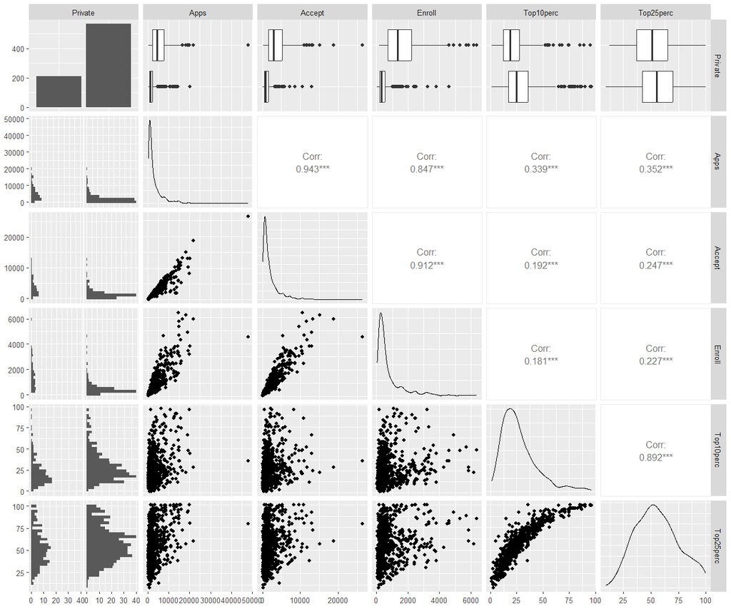

```r
College %>% select(1:6) %>% ggpairs() # uses the GGally package
```

Notice how it shows you the correlation coefficients, and for the Yes-No column `Private`, it shows histograms and boxplots. For instance, we see that `Accept` and `Enroll` are clearly related.

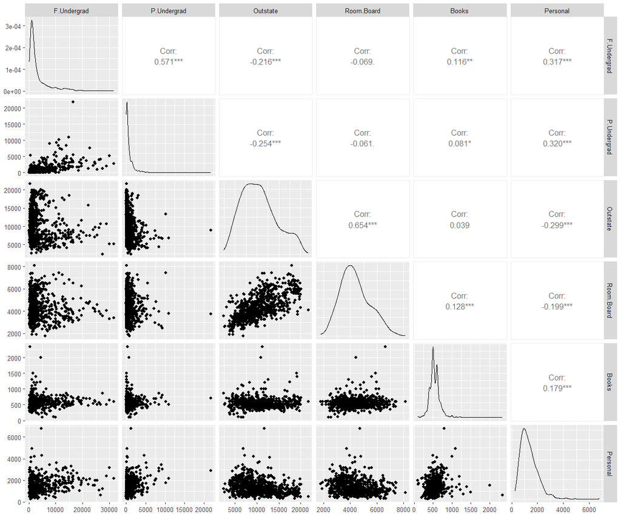

```r
College %>% select(7:12) %>% ggpairs(progress=F) # uses the GGally package
```

Here we see some relation between `Outstate` and `RoomBoard`, the correlation is .654.

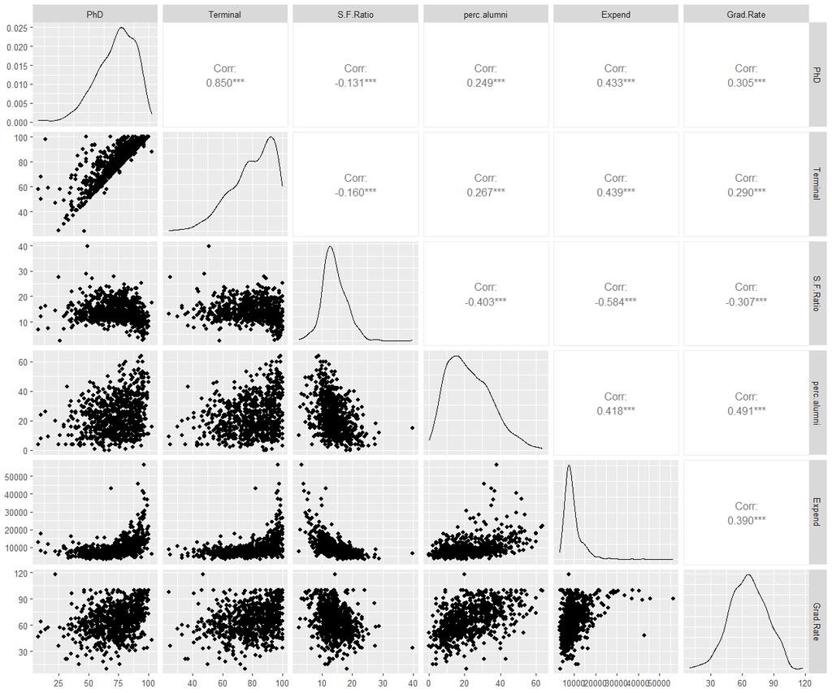

```r
College %>% select(13:18) %>% ggpairs(progress=F) # uses the GGally package
```

Here we can see `Terminal` and `PhD` are closely related with correlation of .85. A `PhD` is a terminal degree in education parlance.

# Part iii

Plot a boxplot of `Private` vs `Outstate`, using `ggplot`.

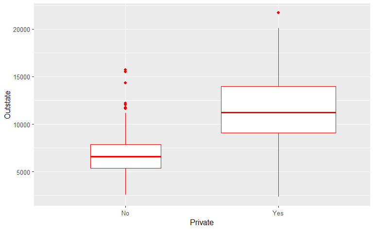

```r
ggplot(College) +
  geom_boxplot(aes(Private, Outstate), color="red", varwidth=TRUE)
```

Axis labels are done for you. It looks like Private colleges have higher out-of-state tuition, on average. The boxplot shows us how the colleges are clustered. Interpretation comes from this quote taken from the documentation for `geom_boxplot`.

> The lower and upper hinges correspond to the first and third quartiles (the 25th and 75th percentiles). This differs slightly from the method used by the boxplot() function, and may be apparent with small samples. See boxplot.stats() for for more information on how hinge positions are calculated for boxplot().

> The upper whisker extends from the hinge to the largest value no further than 1.5 * IQR from the hinge (where IQR is the inter-quartile range, or distance between the first and third quartiles). The lower whisker extends from the hinge to the smallest value at most 1.5 * IQR of the hinge. Data beyond the end of the whiskers are called “outlying” points and are plotted individually.

# Part iv

Create a new qualitative variable `Elite` (Yes or No).  
The new tidyverse way to add a column uses the `mutate()` function and the `case_when` function (a version of if-then-else). It allows you to add new columns by computation.

```r
College = College %>%
  mutate(Elite =
           as.factor(
              case_when(
                Top10perc >50 ~ "Yes",
                .default="No")
            )
          )

College %>% skim(Elite)
```

```
── Data Summary ────────────────────────
                           Values
Name                       Piped data
Number of rows             777
Number of columns          19
_______________________
Column type frequency:
  factor                   1
________________________
Group variables            None
```

|  | skim_variable | n_missing | complete_rate | ordered | n_unique | top_counts |
| --- | --- | --- | --- | --- | --- | --- |
| 1 | Elite | 0 | 1 | FALSE | 2 | No: 699, Yes: 78 |

Reading the code, we can see that the new categorical column `Elite` is computed from the column `Top10perc.` If `Top10perc` is over 50, then `Elite` is given the character value “Yes”; if not, it is given the value “No”. Then the character variable is turned into a factor, the customary way in R of setting up character variables with a small number of values as a 0-1 binary variable.

There are 78 Elite schools and 699 non-Elite schools.

Make boxplots side by side of `Outstate` vs `Elite`.

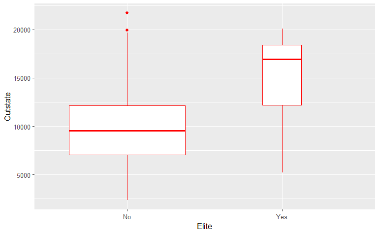

```r
College %>% ggplot() +
  geom_boxplot(aes(Elite, Outstate), color="red", varwidth=TRUE)
```

Elite schools have a lot bigger out-of-state tuition.

# Part v

We make some histograms of `Outstate`, `Apps`, `Grad.Rate`, and `Expend`. We store them in `ggplot` objects, `p1, p2, p3, p4`. We can plot each one by simply stating it.

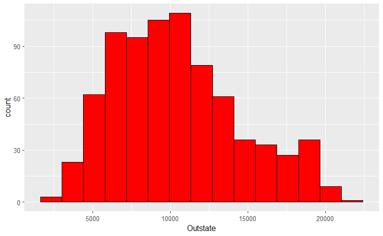

```r
# ggplot way
p1 =  College %>% ggplot() + geom_histogram(aes(Outstate), color="black", bins=15, fill="red")
p2 =  College %>% ggplot() + geom_histogram(aes(Apps), color="black", bins=15, fill="red")
p3 =  College %>% ggplot() + geom_histogram(aes(Grad.Rate), color="black", bins=15, fill="red")
p4 =  College %>% ggplot() + geom_histogram(aes(Expend), color="black", bins=15, fill="red")
p1
```

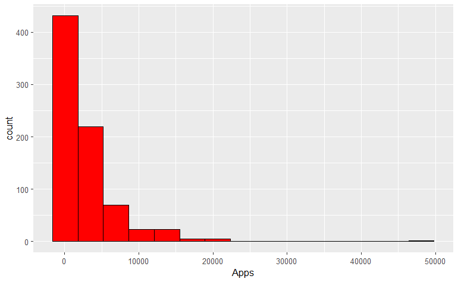

```r
p2
```

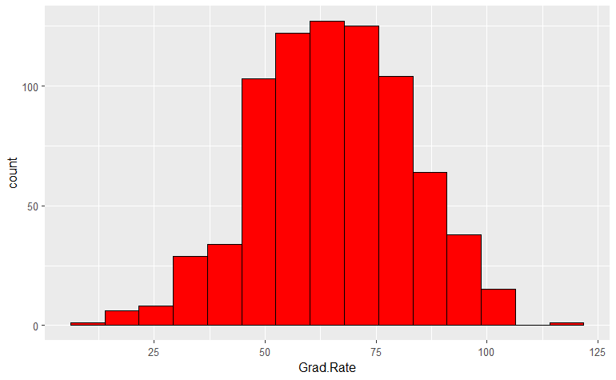

```r
p3
```

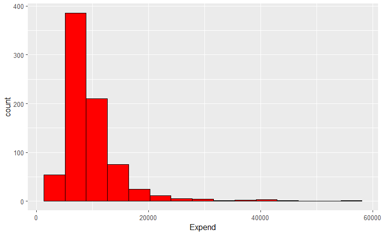

```r
p4
```

Or we can put the plots in an array, using `patchwork`.

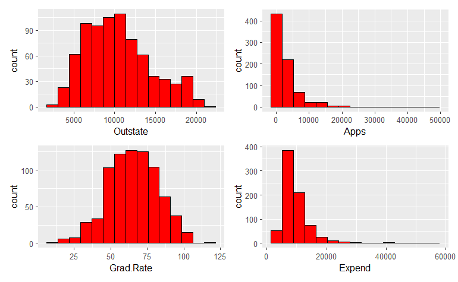

```r
(p1 | p2)/ (p3 | p4)
```

# Part vi

I will just do one thing.

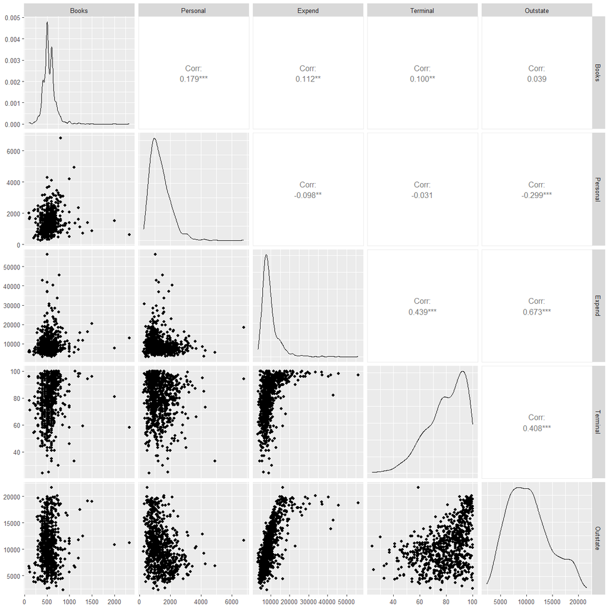

```r
College %>% select(Books,Personal,Expend,Terminal,Outstate) %>%
  ggpairs(progress=F)
```

`Terminal` and `Outstate` seem to have some correlation; `Expend` and `Outstate` are definitely correlated.

# Conclusion

We have solved the problem set. And we have learned a few things about how to manage data and look for meaning in it.

# References

1. ISLR (2013) Applied Exercise 8, Chapter 2, page 54-55.